# ggplot2 Elegant Graphics for Data Analysis

## 10.2 Statistical Considerations

평균이나 중앙값으로 요약할 때 갯수와 분산척도를 포함하는 것이 좋다. 이것을 포함하지 않는다면 잘못된 결론을 내릴 수 있다.

```r
by_clarity <- diamonds %>%
  group_by(clarity) %>%
  summarise(
    n = n(),
    mean = mean(price),
    lq = quantile(price, 0.25),
    uq = quantile(price, 0.75)
  )
by_clarity
```

```
## # A tibble: 8 x 5
##   clarity     n  mean    lq    uq
##   <ord>   <int> <dbl> <dbl> <dbl>
## 1 I1        741 3924. 2080  5161
## 2 SI2      9194 5063. 2264  5777.
## 3 SI1     13065 3996. 1089  5250
## 4 VS2     12258 3925.  900  6024.
## 5 VS1      8171 3839.  876  6023
## 6 VVS2     5066 3284.  794. 3638.
## 7 VVS1     3655 2523.  816  2379
## 8 IF       1790 2865.  895  2388.
```

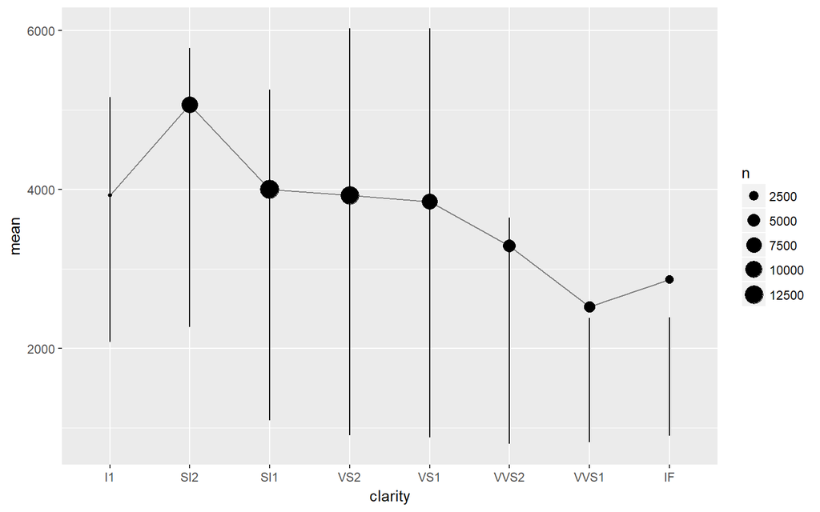

```r
ggplot(by_clarity, aes(clarity, mean)) +
  geom_line(aes(group = 1), colour ="grey 50") +
  geom_point(aes(size = n)) +
  geom_linerange(aes(ymin = lq, ymax = uq))
```

이 데이터에서는 평균이 좋지 않은 요약 통계량임을 알 수 있다. 가격의 분포가 매우 skewed 되어 있기 때문이다.

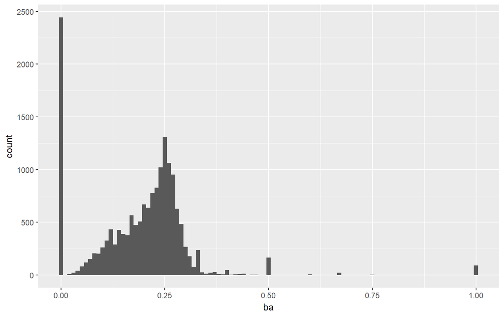

```r
data(Batting, package = "Lahman")
ba <- Batting %>%
  filter(AB > 0) %>%
  group_by(playerID) %>%
  summarise(
    ba = sum(H, na.rm = TRUE) / sum(AB, na.rm = TRUE),
     ab = sum(AB, na.rm = TRUE)
)
ggplot(ba, aes(ba)) +
  geom_histogram(binwidth = 0.01)
```

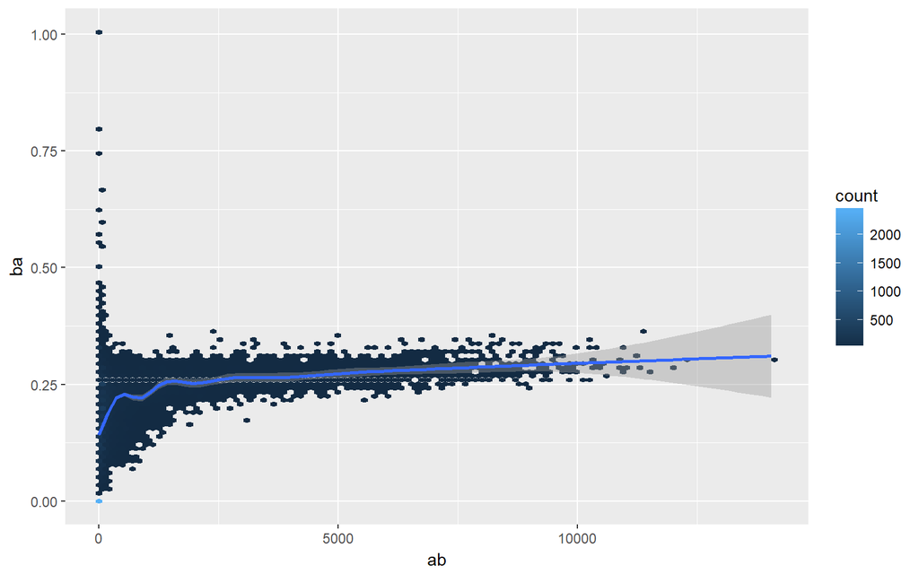

```r
ggplot(ba, aes(ab, ba)) +
  geom_hex(bins = 100) +
  geom_smooth()
```

10번 이하로 베트를 휘두르면 제거

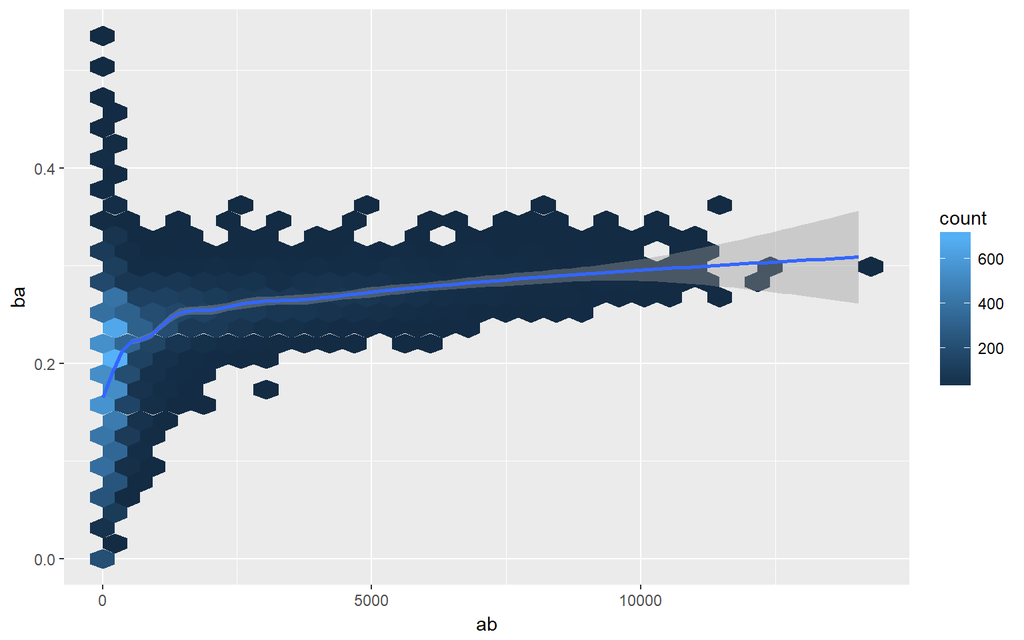

```r
ggplot(filter(ba, ab>= 10), aes(ab, ba)) +
  geom_hex() +
  geom_smooth()
```

## 10.3 Exercises

1. For each year in the ggplot2movies::movies data determine the percent of movies with missing budgets. Visualise the result.

각 년도의 예산결측 비율은 다음과 같다. 다른방법 없을까..

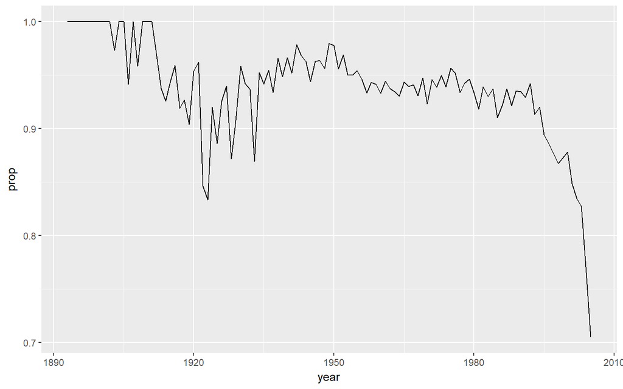

```r
movies_na <- movies %>%
  mutate(count_na = ifelse(is.na(budget), 1, 0)) %>%
  group_by(year, count_na) %>%
  summarise(n = n())

movies_na <- movies_na %>%
  group_by(year) %>%
  mutate(sum_n = sum(n)) %>%
  mutate(prop = n / sum_n) %>%
  filter(count_na == 1)

ggplot(movies_na, aes(year, prop)) +
  geom_line()
```

2. How does the average length of a movie change over time? Display your answer with a plot, including some display of uncertainty.

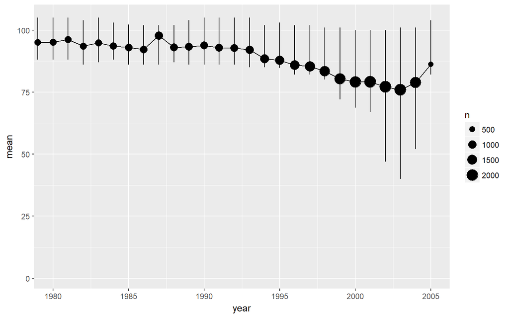

```r
movie_length <- movies %>%
  group_by(year) %>%
  summarise(
    mean = mean(length),
    n = n(),
     lq = quantile(length, 0.25),
    uq = quantile(length, 0.75)
  )

ggplot(movie_length, aes(year, mean)) +
  geom_line() +
  geom_point(aes(size = n)) +
  geom_linerange(aes(ymin = lq, ymax = uq)) +
  scale_size_area() +
  coord_cartesian(xlim = c(1980, 2005))
```

3. For each combination of diamond quality (e.g. cut, colour and clarity), count the number of diamonds, the average price and the average size. Visualise the results.

다이아 수

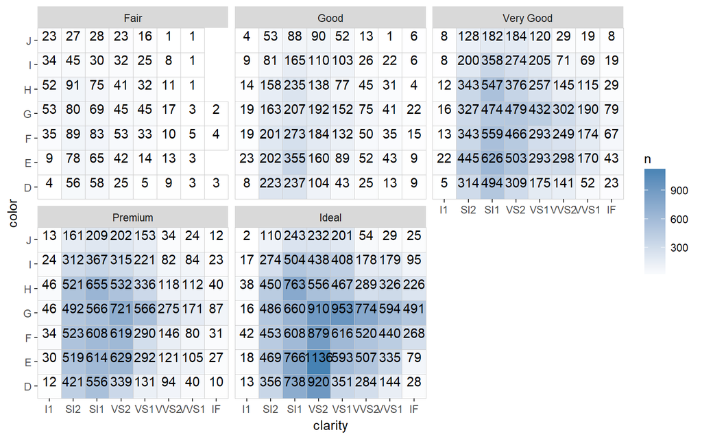

```r
dia_count <- diamonds %>%
  group_by(cut, color, clarity) %>%
  summarise(n = n())
ggplot(dia_count, aes(clarity, color)) +
  geom_tile(aes(fill = n), colour = "grey80") +
  scale_fill_gradient(low = "white", high = "steelblue") +
  geom_text(aes(label = n), vjust = "bottom") +
  facet_wrap(~cut) +
  scale_x_discrete(expand = c(0, 0)) +
  scale_y_discrete(expand = c(0, 0)) +
  theme(panel.grid = element_blank(), panel.background = element_rect(fill = "white"))
```

평균 가격

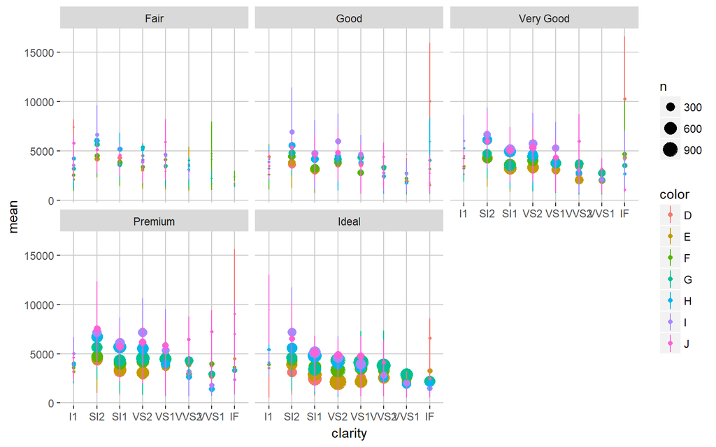

```r
dia_price <- diamonds %>%
  group_by(cut, color, clarity) %>%
  summarise(
    mean = mean(price),
    n = n(),
    lq = quantile(price, 0.25),
    uq = quantile(price, 0.75)
    )

ggplot(dia_price, aes(clarity, mean, colour = color)) +
  geom_point(aes(size = n)) +
  geom_linerange(aes(ymin = lq, ymax = uq)) +
  facet_wrap(~cut) +
  scale_size_area() +
  theme(panel.background = element_rect(fill = "white"),
        panel.grid.major = element_line("grey80"),
        panel.grid.minor = element_blank())
```

여기서 cut의 영향이 크지 않는것 처럼 보이므로 복잡하니까 cut제거.

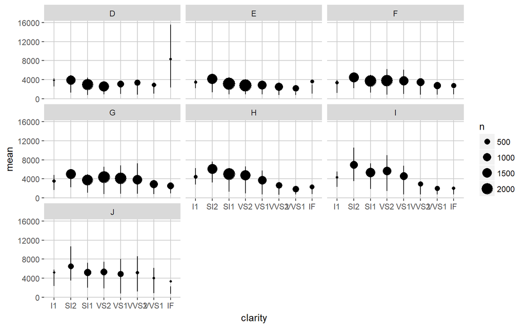

```r
dia_price <- diamonds %>%
  group_by(color, clarity) %>%
  summarise(
    mean = mean(price),
    n = n(),
    lq = quantile(price, 0.25),
    uq = quantile(price, 0.75)
    )
ggplot(dia_price, aes(clarity, mean)) +
  geom_point(aes(size = n)) +
  geom_linerange(aes(ymin = lq, ymax = uq)) +
  facet_wrap(~color) +
  scale_size_area() +
  theme(panel.background = element_rect(fill = "white"),
        panel.grid.major = element_line("grey80"),
        panel.grid.minor = element_blank())
```

품질이 낮은 것들이 highly skewed임을 알 수 있다.

4. Compute a histogram of carat by “hand” using a binwidth of 0.1. Display the results with geom bar(stat = “identity”). (Hint: you might need to create a new variable first.)

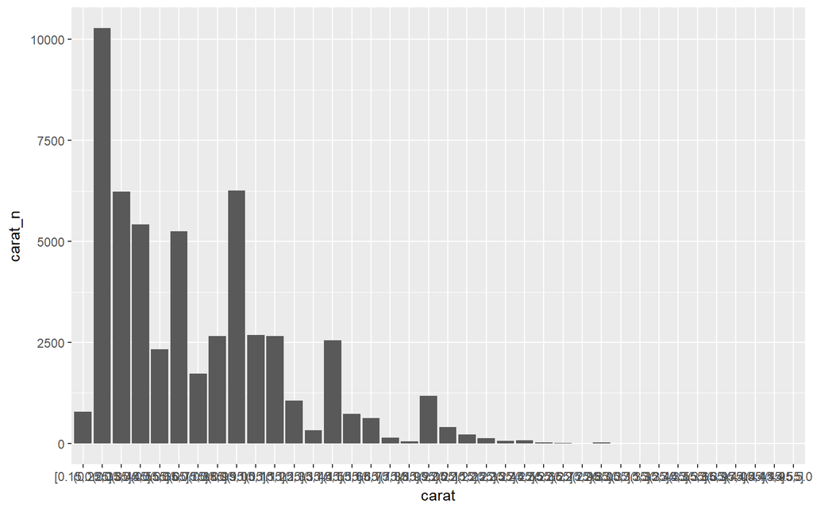

```r
temp <- diamonds %>%
  mutate(carat = cut_width(carat, 0.1)) %>%
  group_by(carat) %>%
  summarise(carat_n = n())

ggplot(temp, aes(carat, carat_n)) +
  geom_col()
```

5. In the baseball example, the batting average seems to increase as the number of at bats increases. Why?

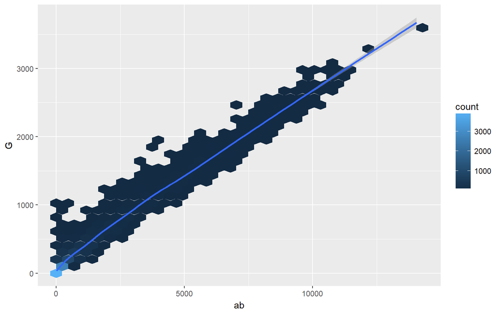

```r
ba <- Batting %>%
  filter(AB > 0) %>%
  group_by(playerID) %>%
  summarise(
    ba = sum(H, na.rm = TRUE) / sum(AB, na.rm = TRUE), ab = sum(AB, na.rm = TRUE),
    G = sum(G, na.rm = TRUE)
)
ggplot(filter(ba, ab>= 10), aes(ab, G)) +
  geom_hex() +
  geom_smooth()
```

아무래도 팀에서는 잘하는 선수를 내보낼 테니까 배트를 많이 휘두르는 선수가 잘 칠것이다.

6. Which player in the Batting dataset has had the most consistently good performance over the course of their career?

# 11 Summary

- x, y관계를 더 잘 탐구하기 위해서 데이터를 대각이 아닌 flat하도록 회전시키는 것은 유용하다
- 로그변환시 곱의 관계를 선형관계로 바꾸어주는데 변환전 볼 수 없었던 관계가 보일 수 있다.
- 두 변수간의 상대적 차이에 관심이 있다면 `log(x / y)`
- 때때로 적분하거나 미분하는것이 해석하기 좋다.
- 수를 `abs(X)`와 `sign(x)`로 나누어 보라.
- 강한 추세를 볼 수 있다면 패턴과 잔차를 나누기 위해 모델링하는 것은 유용하다다
- `geom_freqpoly()`는 범주의 레벨간에 걸쳐 분포를 비교할 때 적합하다. `y = ..density..`와 `binwidth`를 함께 사용하자.
- 평균이나 중앙값으로 요약할 때는 분산척도를 포함하자.
- 테이블 형태의 데이터(두개의 범주형)를 시각화 할때는 히트맵